# Homework 3

## Definitions

Define the following terms/concepts

- a.) Sampling Error
- b.) Law of Large Numbers
- c.) Sample Space
- d.) Event
- e.) Union
- f.) Intersection
- g.) Random Trial
- h.) Random Variable
- i.) Probability distribution
- j.) Population distribution
- k.) Continuous random variable
- l.) Discrete random variable
- m.) Probability Mass Function
- n.) Probability Density Function

## Simple probability

$\bf (1)$ A fair coin is thrown 3 times. What is the probability that at least one heads is observed?

$\bf (2)$ Suppose that in a class of 30 students, 8 students are in band, 15 students play a sport, and 5 students are both in band and play a sport. Let $A$ be the event that a student is in band and let $B$ be the event that a student plays a sport. Create a Venn diagram that models this situation. What is the probability that a student is in the band or plays a sport?

$\bf (3)$ A standard deck of 52 cards contains four suits (Hearts, Diamonds, Clubs, and Spades). Each suit contains 13 cards (9 numbered cards and 3 face cards, and an Ace).

- Suppose a single card is drawn at random, what is the probability that it is a numbered card?
- What is the probability that the selected card is the Ace of Spades (assume independence where necessary)?

$\bf (4)$ An urn contains 5 green balls, 7 red balls, and 4 yellow balls. Two balls are selected at random with replacement. What is the probability that first ball is yellow and the second ball is red?

$\bf (5)$ The probability that it rains $R$ on a given day in Moscow, Idaho is $P(R) = 0.1$. The probability that it is Windy $W$ is $P(W) = 0.2$, and the probability that it is cloudy $C$ is $P(C) = 0.7$. Assume that these three types of weather events are independent. What is the probability that a given day is Rainy, Cloudy, and Windy?

## Sampling Distributions, Means, and Variances

$\bf (6)$ A random variable $X$ has the following probability distribution

| X | P(X) |
| --- | --- |
| 1 | 0.25 |
| 2 | 0.25 |
| 3 | 0.25 |
| 4 | 0.25 |

- Derive the sampling distribution for the mean of $n=2$ observations of $X$
- Compute the mean $\mu_{\bar{X}}$ and standard deviation $\sigma_{\bar{X}}$ of the sampling distribution of $\bar{X}$

$\bf (7)$ A random variable $Y$ has two possible outcomes. The outcome $Y = 1$ occurs with probability $p = 0.23$. Derive the sampling distribution for the proportion of outcomes with $Y = 1$ in a sample of $n = 3$ observations of $Y$.

$\bf (8)$ Consider a survey of tree volume. Suppose that in the population of trees $10\%$ have a volume of 10 cubic feet, $20\%$ have a volume of 20 cubic feet, $30\%$ have a volume of 30 cubic feet, and $40\%$ have a volume of 40 cubic feet. Let $X$ denote the volume of a randomly selected tree, assuming that every tree has an equal chance of being selected. The probability distribution of $X$ is given in the table below.

| X | P(X) |
| --- | --- |
| 10 | 0.1 |
| 20 | 0.2 |
| 30 | 0.3 |
| 40 | 0.4 |

- Confirm that $X$ has a mean of $\mu = 30$ cubic feet and a standard deviation of $\sigma = 10$ cubic feet by computing them yourself.
- Derive the sampling distribution for the mean tree volume in a sample of $n = 2$ trees.

## Deriving Probabilities From Discrete Distributions

| $\bar{X} =$ Mean Punt Distance | $P(\bar{X})$ |
| --- | --- |
| 35.33 | 0.40 |
| 45.67 | 0.50 |
| 55.00 | 0.08 |
| 60.33 | 0.01 |
| 65.67 | 0.01 |

- What is the probability the mean distance is 55 or more yards?
- What is the probability the mean distance is at least 35.33 yards?
- What is the probability the mean distance is between 35.33 and 45.67 yards?
- What is the probability the mean distance is 35.33 yards or 55 yards?

$\bf (10)$ A random variable $X$ follows a binomial distribution with probability of success $p = 0.43$ and number of trials $n = 8$. What is the probability of observing fewer than 3 successes, that is what is $P(X < 3)$?

$\bf (11)$ Tom Brady is a famous quarterback who recently retired from playing in the National Football League. During his career, the probability that Brady would complete a pass in a given play was $64.3\%$. If a typical NFL team runs about $35$ offensive pass plays, what is the probability that Brady would complete exactly $28$ pass plays in a game?

$\bf (12)$ A random variable $W$ follows a Poisson distribution with rate parameter $\lambda = 1.8$ events per hour. What is the probability of observing exactly four events in a given hour, that is what is $P(W = 4)$?

$\bf (13)$ A factory experiences on average 3 equipment malfunctions per day, following a Poisson distribution with a rate parameter of 3. Calculate the probability that on a randomly selected day, the factory will observe 3 or more equipment malfunctions.

## Deriving Probabilities From Continuous Distributions

${\bf (14)}$ Use the plot below of the probability distribution of a continuous random variable $X$ to answer the following questions

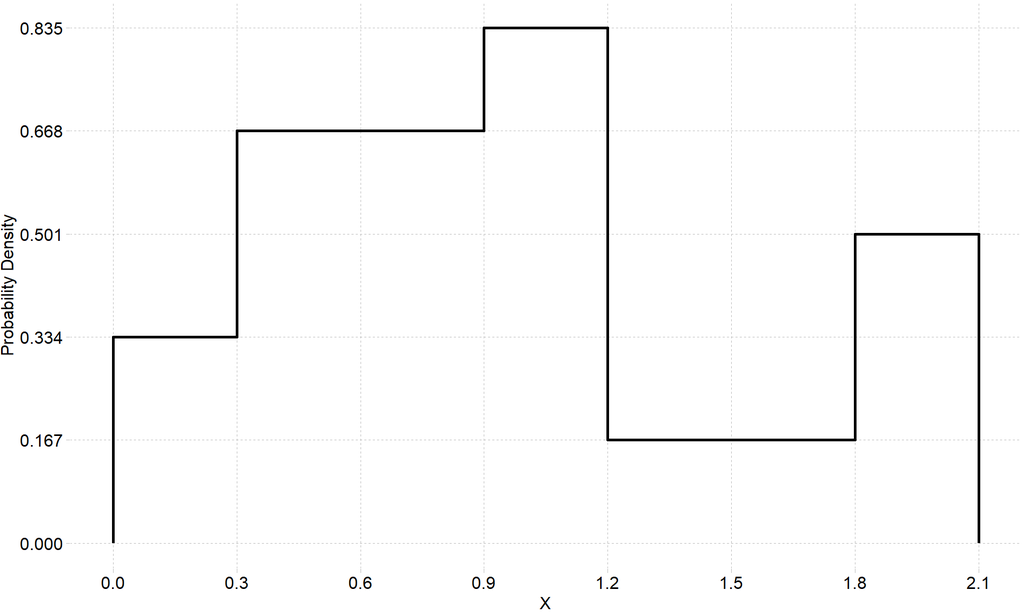

Use the plot to find the following probabilities:

- What is $P(X<0.6)$?
- What is $P(X>0.3)$?
- What is $P(1.5<X<1.8)$?

${\bf (15)}$ Use the plot below of the probability distribution of a continuous random variable $Y$ to answer the following questions

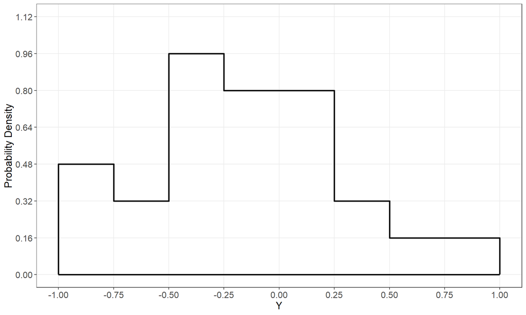

Use the plot to find the following probabilities (recall that the area of a triangle is $\frac{1}{2} \times \text{base} \times \text{height}$)

- What is $P(Y>-0.25)$?
- What is $P(-0.5<Y<0.25)$?

${\bf (16)}$ Use the plot below of the probability distribution of a continuous random variable $Z$ to answer the following questions

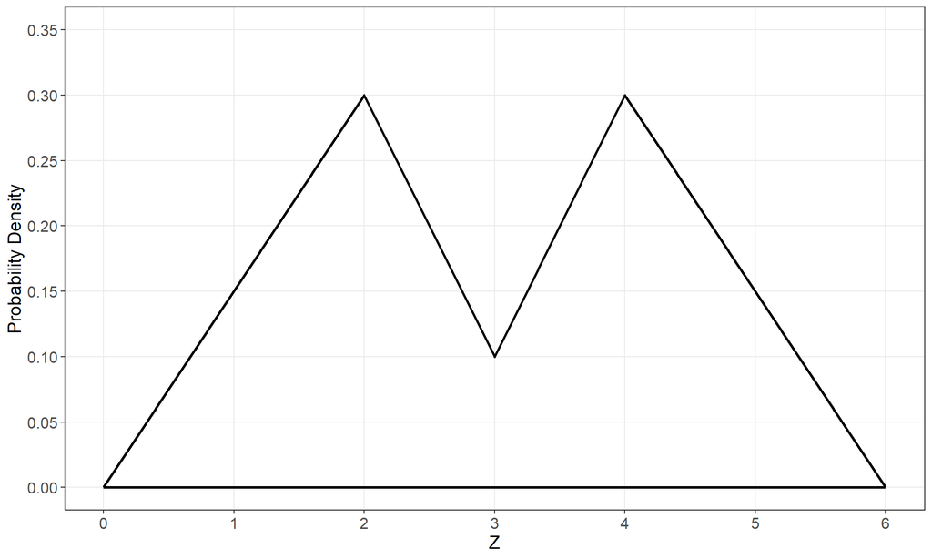

Use the plot to find the following probabilities (recall that the area of a triangle is $\frac{1}{2} \times \text{base} \times \text{height}$)

- What is $P(Z<2)$?
- What is $P(2<Z<3)$?
- What is $P(Z>4)$?
- Give the approximate value of the $25th$ percentile of distribution of $Z$

${\bf 17.)}$ Assume the continuous random variable $X$ follows a normal distribution with mean $\mu = 25$ and variance $\sigma^2 = 16$.

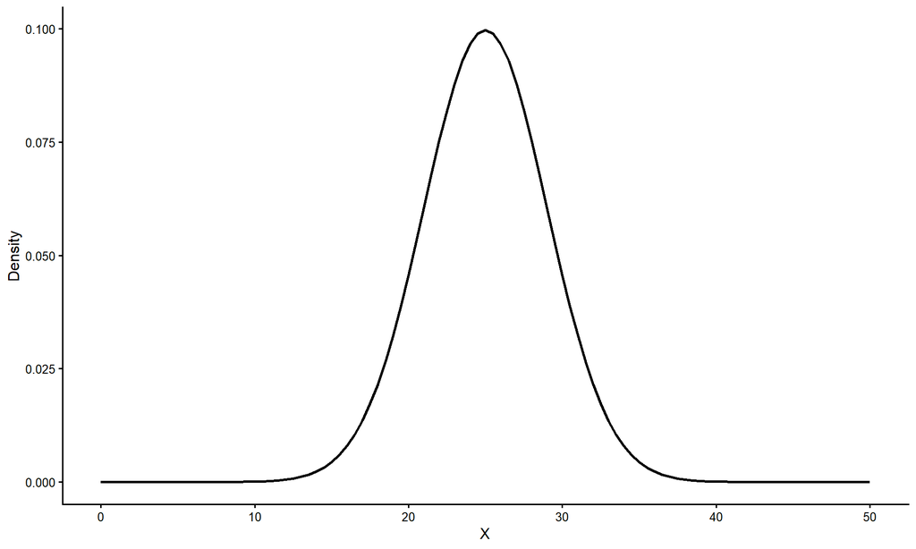

Using a $Z$-table, find the following (approximate) probabilities for $X$. You can also use the app in the course website or [StatDistributions.com](http://www.statdistributions.com/normal/) to check your result

- What is $P(X<15)$?
- What is $P(X>28)$?
- What is $P(12<X<20)$?
- What is $P(X>30)$?
- What is $P(25<X<33)$?
- What is the value of $X$ that marks the $95th$ percentile of the distribution?
- What is the value of $X$ that marks the $40th$ percentile of the distribution?

${\bf 18.)}$ Suppose that a random variable $X$ follows a normal distribution with mean $\mu = -5$ and standard deviation $\sigma = 1.8$. Using the plot of the $Z$-distribution below, shade in the area corresponding to the probability $P(-2< X <0.5)$

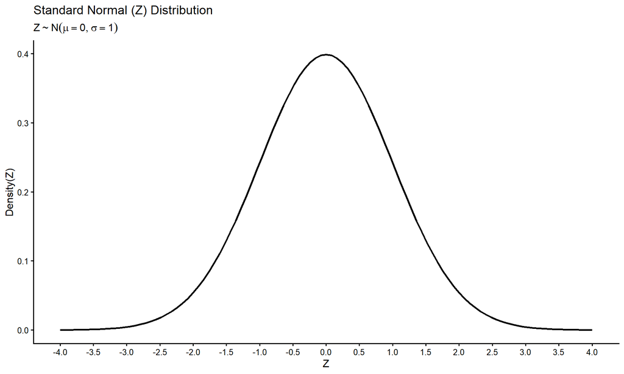